# Администрирование локальных сетей

Лабораторная работа №10

Илья Колонтырский

Российский университет дружбы народов, Москва, Россия

14.04.2026

# Цель работы

## Цель лабораторной работы

Освоить настройку списков управления доступом (ACL) и проверить разграничение доступа пользователей к ресурсам сети.

## Основные задачи

- подключить административный узел в сеть;
- задать статическую IP-конфигурацию;
- настроить расширенные ACL на маршрутизаторе;
- разрешить доступ к web-, file-, mail- и DNS-серверам;
- предоставить отдельные права административным узлам;
- проверить доступность сервисов и корректность ограничений.

# Подключение администратора

## Подключение устройства администратора в топологию

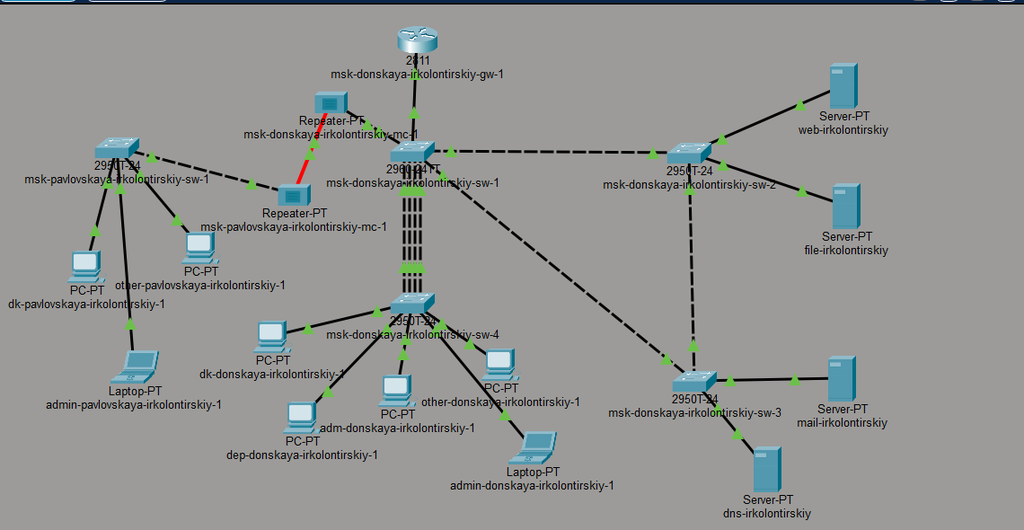

Подключение ноутбука администратора в общей топологии сети

## Настройка IP-параметров административных узлов

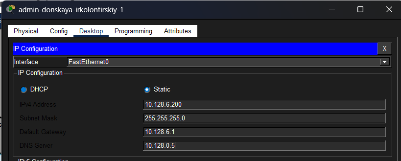

Настройка IP-параметров узла admin-donskaya-irkolontirskiy-1

## Настройка IP-параметров административных узлов

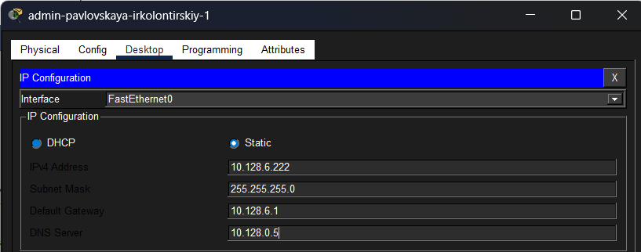

Настройка IP-параметров узла admin-pavlovskaya-irkolontirskiy-1

# Настройка ACL для серверного сегмента

## Создание ACL и правила HTTP-доступа

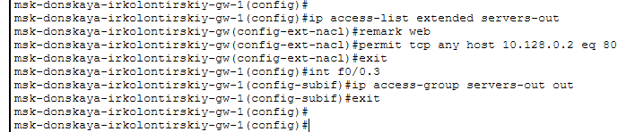

Создание ACL и правила доступа по HTTP

## Проверка доступа к web-серверу

- web-страница по адресу **http://10.128.0.2** открывается успешно;
- проверка через **ping** завершается ошибкой;
- причина: **ICMP-трафик ещё не разрешён в ACL**.

## Проверка web-доступа и запрета ICMP

[figure not shown]

Проверка доступа к web-серверу через браузер

## Проверка web-доступа и запрета ICMP

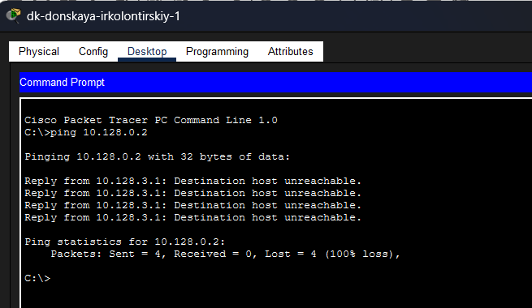

Проверка доступа командой ping

# Доступ администратора к web-серверу

## Добавление правил для FTP и Telnet

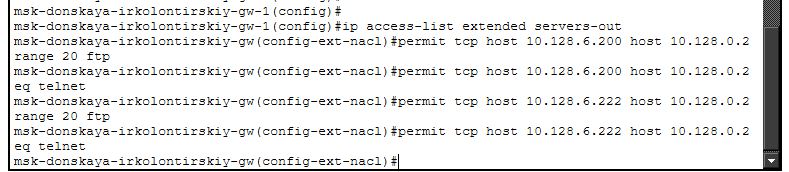

Добавление правил для FTP и Telnet

## Проверка FTP-доступа администратора

Проверка показала: - администратор **10.128.6.200** успешно подключается к FTP-серверу; - второй административный узел **10.128.6.222** также получает доступ; - пользовательские устройства без разрешающего правила подключиться не могут.

## Результаты проверки FTP-доступа

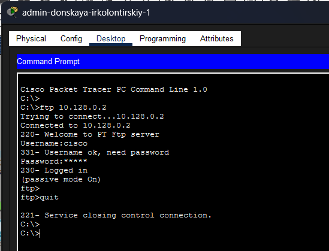

Успешное FTP-подключение администратора

## Результаты проверки FTP-доступа

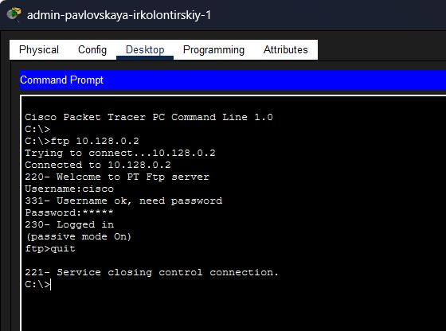

Успешное FTP-подключение второго администратора

## Результаты проверки FTP-доступа

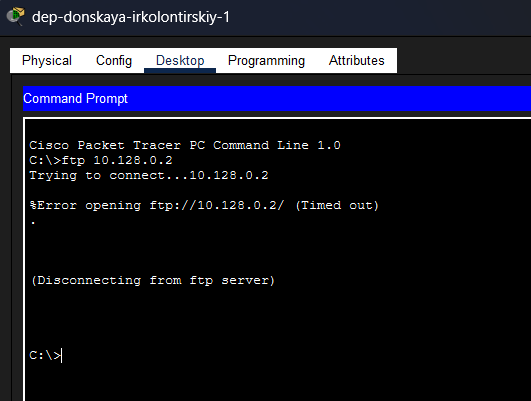

Попытка FTP-подключения с другого устройства

# Доступ к файловому серверу

## Настройка доступа к файловому серверу

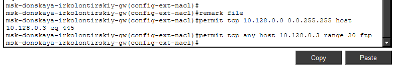

Добавление правил ACL для доступа к файловому серверу

## Проверка доступа к файловому серверу

С административного узла было выполнено успешное FTP-подключение к серверу **10.128.0.3** с использованием учётной записи **cisco**.

## Проверка FTP-доступа к файловому серверу

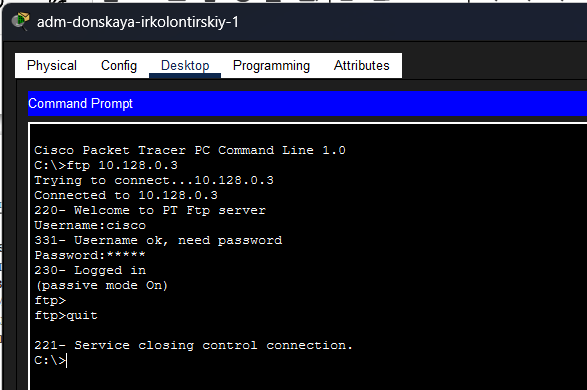

Проверка FTP-доступа к файловому серверу

# Доступ к почтовому и DNS-сервисам

## Настройка ACL для mail и DNS

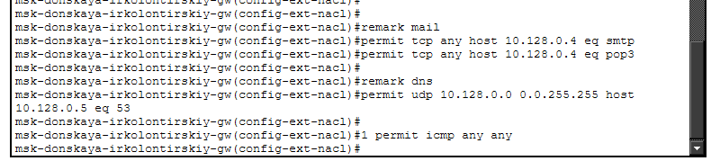

Добавление правил ACL для доступа к DNS-серверу

# Разрешение ICMP

## Разрешение ICMP-трафика

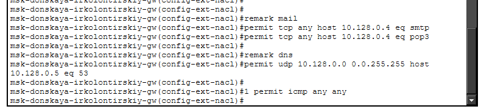

Добавление правила разрешения ICMP в начало списка ACL

# ACL для административного доступа

## Настройка административного доступа

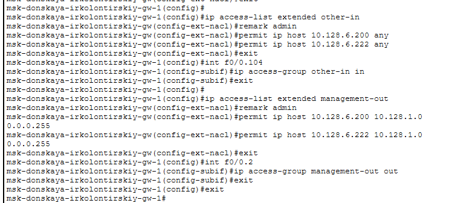

Настройка ACL other-in и management-out для административного доступа

# Настройка почтовых клиентов

## Настройка почтовых клиентов

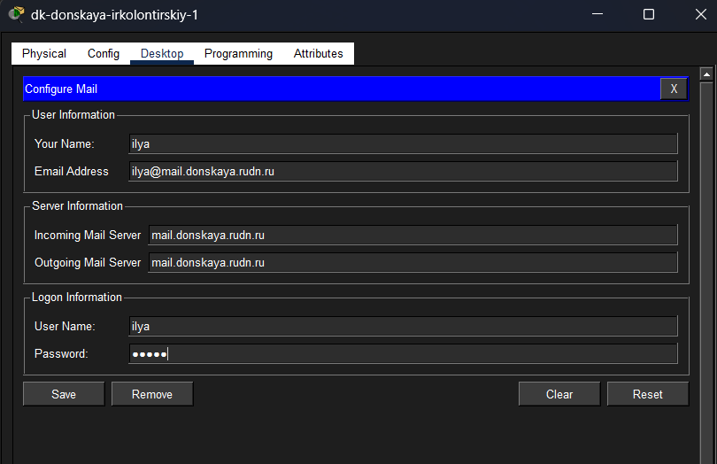

Настройка почтового клиента пользователя ilya

## Настройка почтовых клиентов

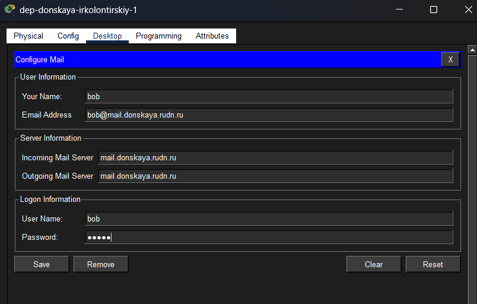

Настройка почтового клиента пользователя bob

## Проверка работы почтового сервиса

Проверка показала:

- пользователь **ilya** успешно отправил сообщение пользователю **bob**;
- было получено ответное письмо с темой **RE: test**;
- DNS-имя **mail.donskaya.rudn.ru** успешно разрешается в **10.128.0.4**;
- SMTP и POP3 работают корректно.

## Проверка почтового обмена

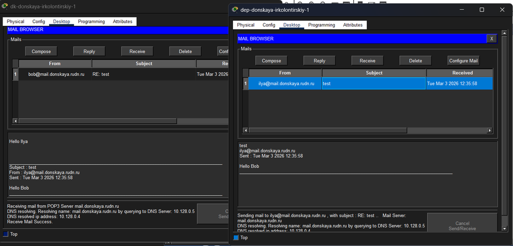

Проверка обмена почтовыми сообщениями между пользователями

# Проверка DNS и ICMP

## Проверка web-доступа по доменному имени

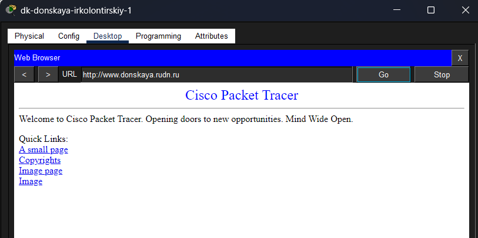

Проверка доступа к web-серверу по доменному имени

## Проверка ICMP-доступа

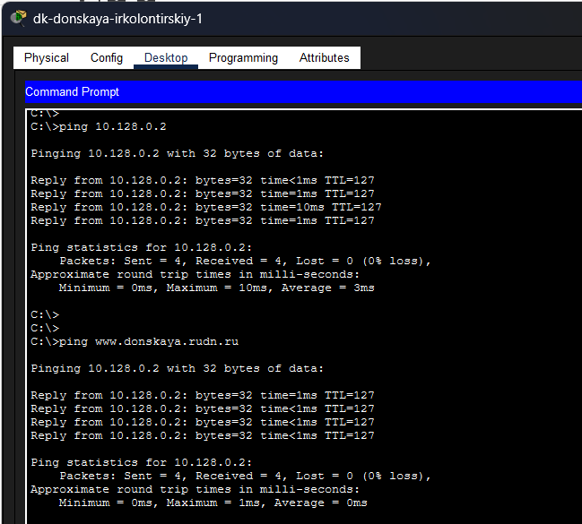

Проверка ICMP-доступа к серверу по IP-адресу и имени

# Проверка доступа к сетевому оборудованию

## Проверка ACL на маршрутизаторе

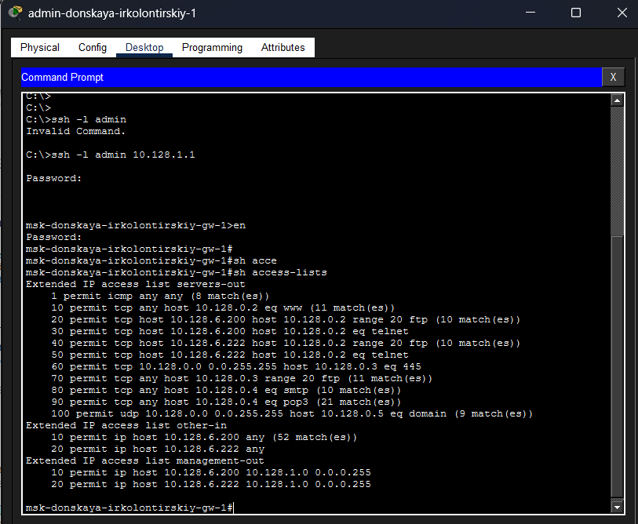

Проверка ACL и подключение к маршрутизатору по SSH

## Подключение к коммутатору по SSH

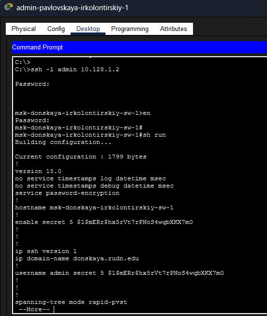

Подключение к коммутатору по SSH и просмотр конфигурации

# Выводы

## Вывод

В ходе работы была выполнена настройка расширенных списков управления доступом (**ACL**) для разграничения доступа пользователей к сетевым ресурсам.

Были реализованы: - доступ к **web-, file-, mail- и DNS-серверам**; - отдельные разрешения для **административных узлов**; - контроль доступа к сети управления и сетевому оборудованию; - разрешение только необходимых протоколов и сервисов.